# Probability and Statistics

## Probability Distribution

A probability distribution is the mathematical function that gives the probabilities of occurrence of different possible outcomes for an experiment.

It is a mathematical description of a random phenomenon in terms of its sample space and the probabilities of events (subsets of the sample space).

## Joint Probability Distribution

Given $N$ set of events that are defined on the same probability space, the joint probability distribution is the corresponding probability distribution on all possible combinations of outputs.

### Example of Probability Distributions

Say you are going to toss 2 coins, the probability distributions of each one are:

$$ P(C_1=H)=0.4 \\ P(C_2=H)=0.2 $$

What is the probability distribution of get each combination between heads and tails?

| Coin 1 | Coin 2 | Probability |
| --- | --- | --- |
| H | H | 0.08 |
| H | T | 0.32 |
| T | H | 0.12 |
| T | T | 0.48 |

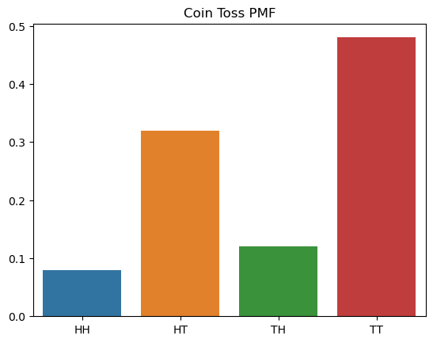

```python
ax.figure
```

## Marginal Probability Distribution

The marginal distribution of a subset of a collection of events is the probability distribution of the events contained in the subset.

### Example of Marginal Probability Distribution

Say you have the joint probability distribution defined below

| Coin 1 | Coin 2 | Probability |
| --- | --- | --- |
| H | H | 0.1 |
| H | T | 0.3 |
| T | H | 0.1 |
| T | T | 0.5 |

What is the probability of toss the 2 coins and get a head in the second one?

$$ P(C_2=H) = P(C_1=H, C_2=H) + P(C_1=T, C_2=H) = 0.1 + 0.1 = 0.2 $$

## Random Variable

A random variable its a mapping or a function from possible outcomes in a sample space to a measurable space, often the real numbers.

### Example of a Random Variable

Say you are going to toss 5 coins. Let $X$ the ranadom variable that counts the number of heads in a thrown. What in the value of $X$ in:

- HHTHT
- HTTHT
- HHHHH

Now let $Y$ the random variable that measure the percent of heads in a thrown. What is the value of $Y$ in each one of the previous examples?

## Expected Value

The expected value of a random variable with a finite number of outcomes is a weighted average of all possible outcomes. In the case of a continuum of possible outcomes, the expectation is defined by integration.

$$ \mu=\mathbb{E}[X] = \sum_{x \in \text{Im}(X)} x Pr(X=x) $$$$ \mu=\mathbb{E}[X] = \int_{-\infty}^{\infty} x f(x)dx $$

Usually, it is denoted as $\mu$.

### Example of Discrete Expected Value

Say you are going to toss 2 coins. The probability distribution of possible outcomes is given by

| Coin 1 | Coin 2 | Probability |
| --- | --- | --- |
| H | H | 0.08 |
| H | T | 0.32 |
| T | H | 0.12 |
| T | T | 0.48 |

Let $X$ the ranadom variable that counts the number of heads in a thrown. What is the expected value of $X$?

$$ \mu=\mathbb{E}[X]=0(0.48)+1(0.32 + 0.12)+2(0.08)=0+0.44+0.16=0.6 $$

What it means?

### Example of a Continuous Expected Value

Let $X$ the random variable that measures the temperature in the city for tomorrow, and $X\sim\mathcal{N}(\mu=23, \sigma^2=4)$. What is the expected temperature for tomorrow?

$$ \mu=\mathbb{E}[X]=\int_{x=-\infty}^{\infty}x\mathcal{N}(23, 4)(x)dx $$

## Linearity of the Expected Value

Fortunately, the expected value is a linear operator, it means that

$$ \mathbb{E}[X+Y]=\mathbb{E}[X]+\mathbb{E}[Y]\\ \mathbb{E}[cX]=c\mathbb{E}[X] $$

where $X$ and $Y$ are random variables and $c$ is a constant. An important property is that linearity is true regardless of $X$ and $Y$ are independent.

## Variance

In probability, variance is the expectation of the squared deviation of a random variable.

It is usually denoted as $\sigma^2$ or $Var(X)$. The squared root of the variance is named standard deviation.

### Example of Discrete Variance

Say you are going to toss 2 coins. The probability distribution of possible outcomes is given by

| Coin 1 | Coin 2 | Probability |
| --- | --- | --- |
| H | H | 0.08 |
| H | T | 0.32 |
| T | H | 0.12 |
| T | T | 0.48 |

Let $X$ the ranadom variable that counts the number of heads in a thrown. The expected value of $X$ is 0.6. What is the variance of $X$?

$$ \sigma^2=\mathbb{E}[X^2]-(\mathbb{E}[X])^2\\ =0^2(0.48)+1^2(0.32 + 0.12)+2^2(0.08)-(0.6)^2\\ =0+0.44+0.32-0.36=0.4 $$